# Relatorio_1

Rodolfo Viana

27-03-2016

# Câncer de Prostata

Antígeno Prostático Específico (PSA) é uma substância produzida pelas células da glândula prostática. O PSA é encontrado principalmente no sêmen, mas uma pequena quantidade é também encontrada no sangue. A maioria dos homens saudáveis têm níveis menores de 4ng/ml de sangue. Nosso objetivo final será predizer a variável psa a partir dos preditores disponíveis.

Utilizamos nesse problema os dados referentes a exames em pacientes homens, afim de identificar sintomas de câncer de prostata. O dataset é composto por dez variáveis:

Como campos do dataset, temos:

- vol: volume do câncer
- weight: peso do paciente
- age: idade do paciente
- bph: hiperplasia prostática benigna
- svi: invasão das vesículas seminais
- cp: penetração capsular
- gleason: escore Gleason
- pgg45: percentagem escore Gleason 4 ou 5
- psa: antígeno específico da próstata (esta é a variável resposta).

```r
library(dplyr)
library(ggplot2)
library(caret)
```

Carregando os dados e dividindo em treino e teste

```r
prostate <- read.delim("/home/rodolfo/Projetos/DataAnalysis/LinearRegression/dados/prostate.data")

prostate.train <- filter(prostate, train == TRUE)
prostate.teste <- filter(prostate, train == FALSE)
```

A princípio iremos fazer uma análise descritiva dos dados e uma análise de correlação das variáveis para identificar possíveis redundâncias.

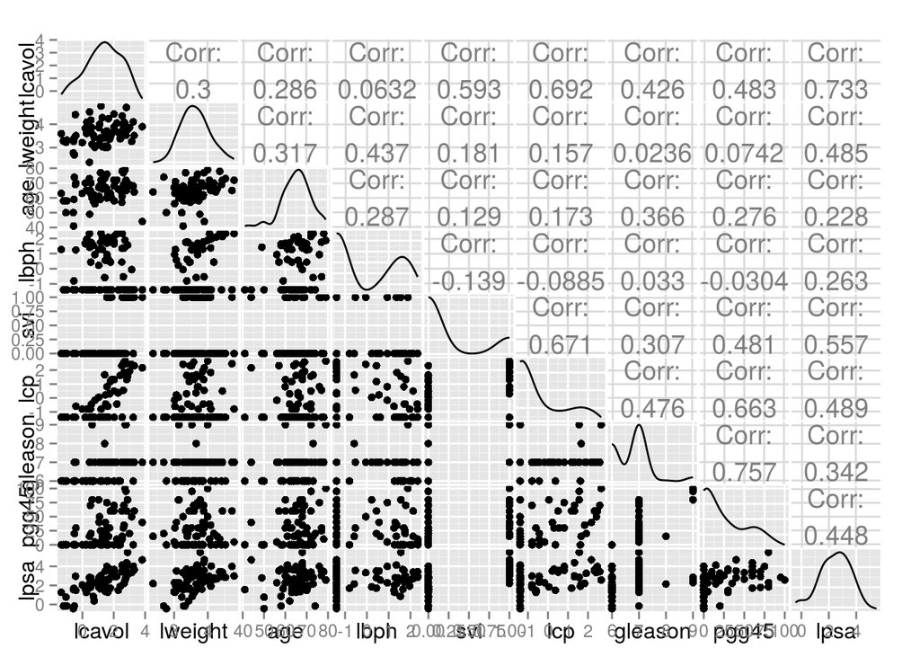

```r
library(GGally)
ggpairs(select(prostate.train, lcavol, lweight, age, lbph, svi, lcp, gleason, pgg45, lpsa))
```

O gráfico acima possui diversas informações, para essa parte do problemas focamos apenas na busca de alguma variável que tenha alguma impacto na variável lpsa. Estamos buscando a variável que mais tem correlação com a variável lpsa. Por essa razão escolhemos a variável lcavol por ser a varável que possui maior correlação 0.733.

Analisando o lcavol e o lpsa mais de perto temos

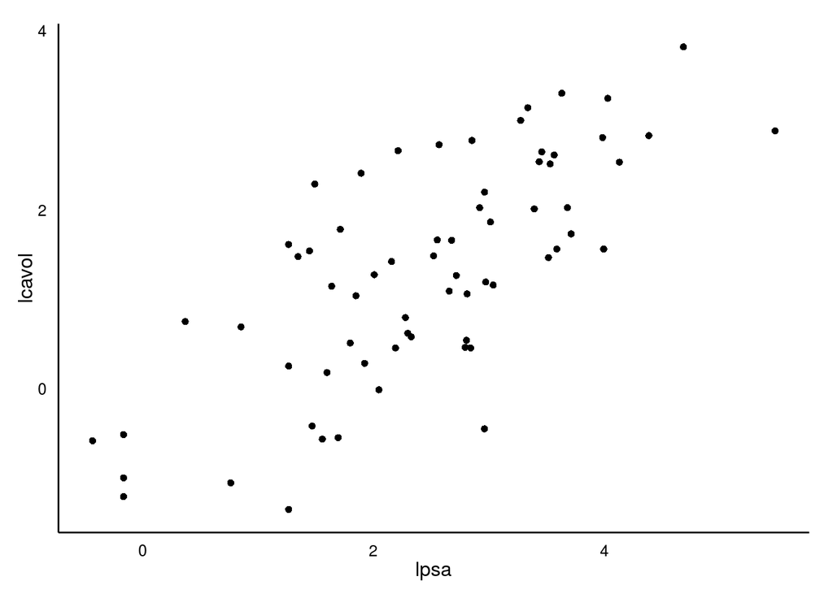

```r
ggplot(prostate.train, aes(lpsa, lcavol)) +
  geom_point() +
  theme_classic() +
  theme(axis.ticks = element_blank(),
        legend.position="none")
```

Podemos notar que essas duas variáveis sugere uma relação linear

Iremos agora construir o nosso primeiro modelo. Esse modelo será bem basico com apenas uma variável e vai servir como base para os outros modelos.

```r
mod_1 <- lm(lpsa ~ lcavol, data = prostate.train)
summary(mod_1)
```

```
##
## Call:
## lm(formula = lpsa ~ lcavol, data = prostate.train)
##
## Residuals:
##     Min      1Q  Median      3Q     Max
## -1.6802 -0.4240  0.1684  0.5392  1.9070
##
## Coefficients:
##             Estimate Std. Error t value Pr(>|t|)
## (Intercept)  1.51630    0.14772  10.264 3.12e-15 ***
## lcavol       0.71264    0.08199   8.692 1.73e-12 ***
## ---
## Signif. codes:  0 '***' 0.001 '**' 0.01 '*' 0.05 '.' 0.1 ' ' 1
##
## Residual standard error: 0.8277 on 65 degrees of freedom
## Multiple R-squared:  0.5375, Adjusted R-squared:  0.5304
## F-statistic: 75.55 on 1 and 65 DF,  p-value: 1.733e-12
```

É possível notar que temos alta a significância de que é pouco provável o fato de que não exista nenhuma relação entre as variáveis lpsa e lcavol. Há evidência de que a relação entre essas duas variáveis seja forte, dado que o R-squared igual à 0,53. O que siginifica que a variável escolhidas explica em 53% a variável resposta (lpsa).

Após criado o modelo, iremos prever utilizando os dados de teste. Para entender melhor a diferença do que foi previsto e do valor esperado podemos observar o gráfico abaixo:

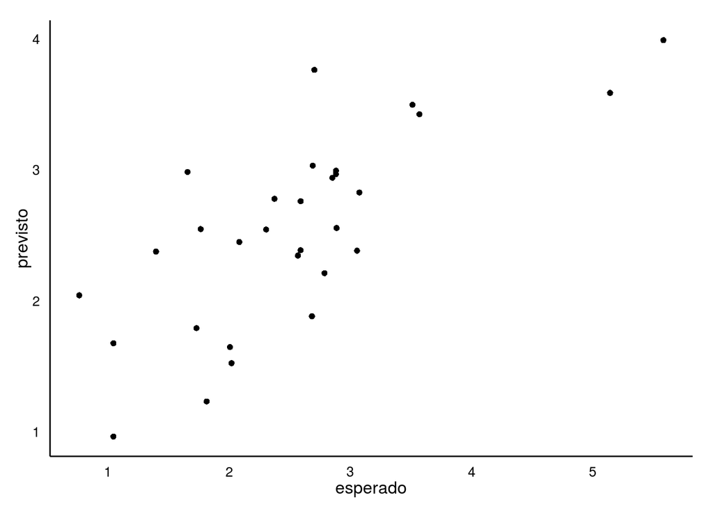

```r
predicoes = predict.lm(mod_1, prostate.teste)

toPlot <- data.frame(esperado = prostate.teste$lpsa,
                     previsto = predicoes)

residuos <- toPlot$esperado - toPlot$previsto

ggplot(toPlot, aes(esperado, previsto)) +
  geom_point() +
  theme_classic() +
  theme(axis.ticks = element_blank(),
        legend.position="none")
```

Em um modelo ideal todos os pontos estariam formando uma linha na diagonal do gráfico. Podemos notar que, considerando que estamos usando apenas uma variável, temos um modelo considerado razoável.

```r
RMSE(toPlot$previsto, toPlot$esperado)
```

```
## [1] 0.6926317
```

RMSE foi de 0.69

É importante também verificar se os resíduos seguem uma distribuição normal com média 0:

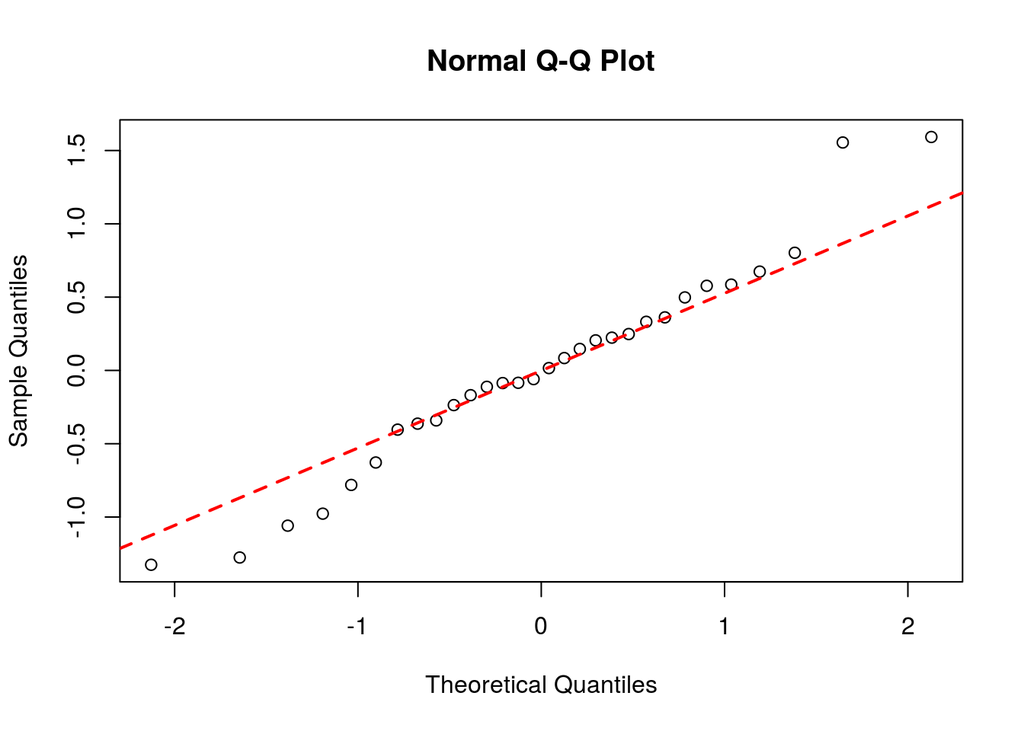

```r
qqnorm(residuos)
qqline(residuos, col = 2,lwd=2,lty=2)
```

Na maior parte os resíduos seguem uma distribuição normal.

```r
mod_3 <- lm(lpsa ~ lcavol + svi, data = prostate.train)
predicoes = predict.lm(mod_3, prostate.teste)

toPlot <- data.frame(esperado = prostate.teste$lpsa,
                     previsto = predicoes)

residuos <- toPlot$esperado - toPlot$previsto

linear_rmse <- RMSE(toPlot$previsto, toPlot$esperado)
linear_rmse
```

```
## [1] 0.6213851
```

Com esse novo modelo temos um RMSE mais baixo do que o anterior. O que significa que o nosso modelo errou menos do que o modelo anterior.

Adicionamos mais uma variável ao nosso modelo. Escolhemos as variáveis lcp utilizando o mesmo critério anterior.

```r
mod_2 <- lm(lpsa ~ lcavol + lcp + svi, data = prostate.train)
predicoes = predict.lm(mod_2, prostate.teste)

toPlot <- data.frame(esperado = prostate.teste$lpsa,
                     previsto = predicoes)

residuos <- toPlot$esperado - toPlot$previsto

RMSE(toPlot$previsto, toPlot$esperado)
```

```
## [1] 0.6654602
```

Com esse novo modelo temos um RMSE mais alto do que o anterior. O que significa que o nosso modelo errou mais que o anterior. Isso pode ter resultado de uma variável pouco importante para o modelo.

```r
summary(mod_2)
```

```
##
## Call:
## lm(formula = lpsa ~ lcavol + lcp + svi, data = prostate.train)
##
## Residuals:
##     Min      1Q  Median      3Q     Max
## -1.7015 -0.5090  0.1243  0.5160  1.6985
##
## Coefficients:
##             Estimate Std. Error t value Pr(>|t|)
## (Intercept)   1.3722     0.1952   7.030 1.77e-09 ***
## lcavol        0.6754     0.1144   5.903 1.55e-07 ***
## lcp          -0.1395     0.1103  -1.265   0.2104
## svi           0.7290     0.3296   2.212   0.0306 *
## ---
## Signif. codes:  0 '***' 0.001 '**' 0.01 '*' 0.05 '.' 0.1 ' ' 1
##
## Residual standard error: 0.8093 on 63 degrees of freedom
## Multiple R-squared:  0.5714, Adjusted R-squared:  0.551
## F-statistic:    28 on 3 and 63 DF,  p-value: 1.256e-11
```

Iremos agora criar um modelo otimizado utilizando Lasso. O Lasso é uma técnica que, além de controlar o overfitting, aplica a seleção de variáveis que melhor explicam a variável resposta. Para criar esse modelo iremos utilizar a biblioteca caret.

Primeiramente vamos criar um modelo no caret com todas as variáveis possíveis.

```r
treino_labels = prostate.train[, 10] ## Classes das instâncias de treino
treino = prostate.train[-c(1,10,11)] ## Exclui variável alvo

lmFit <- train(treino, treino_labels, method= "lm", metric="RMSE")

summary(lmFit)
```

```
##
## Call:
## lm(formula = .outcome ~ ., data = dat)
##
## Residuals:
##      Min       1Q   Median       3Q      Max
## -1.64870 -0.34147 -0.05424  0.44941  1.48675
##
## Coefficients:
##              Estimate Std. Error t value Pr(>|t|)
## (Intercept)  0.429170   1.553588   0.276  0.78334
## lcavol       0.576543   0.107438   5.366 1.47e-06 ***
## lweight      0.614020   0.223216   2.751  0.00792 **
## age         -0.019001   0.013612  -1.396  0.16806
## lbph         0.144848   0.070457   2.056  0.04431 *
## svi          0.737209   0.298555   2.469  0.01651 *
## lcp         -0.206324   0.110516  -1.867  0.06697 .
## gleason     -0.029503   0.201136  -0.147  0.88389
## pgg45        0.009465   0.005447   1.738  0.08755 .
## ---
## Signif. codes:  0 '***' 0.001 '**' 0.01 '*' 0.05 '.' 0.1 ' ' 1
##
## Residual standard error: 0.7123 on 58 degrees of freedom
## Multiple R-squared:  0.6944, Adjusted R-squared:  0.6522
## F-statistic: 16.47 on 8 and 58 DF,  p-value: 2.042e-12
```

Iremos excluir as variáveis com pouca significância (age, lcp, gleason, pgg45). Além disso, vamos realizar o treino utilizando a cross validation.

```r
treino_labels = prostate.train[, 10] ## Classes das instâncias de treino
treino = prostate.train[c(2,3,5,6)] ## Exclui variável alvo

con <- trainControl(method="cv", number=10)

lmFit <- train(treino, treino_labels, method= "lm", metric="RMSE",  trControl = con)

test <- prostate.teste[c(2,3,5,6)]

lmfit_prediction <- predict(lmFit, test)

toPlot <- data.frame(esperado = prostate.teste$lpsa,
                     previsto = lmfit_prediction)

lmfit_rmse <- RMSE(toPlot$previsto, toPlot$esperado)

summary(lmFit)
```

```
##
## Call:
## lm(formula = .outcome ~ ., data = dat)
##
## Residuals:
##     Min      1Q  Median      3Q     Max
## -1.8709 -0.3903 -0.0172  0.5676  1.4227
##
## Coefficients:
##             Estimate Std. Error t value Pr(>|t|)
## (Intercept) -0.32592    0.77998  -0.418   0.6775
## lcavol       0.50552    0.09256   5.461 8.85e-07 ***
## lweight      0.53883    0.22071   2.441   0.0175 *
## lbph         0.14001    0.07041   1.988   0.0512 .
## svi          0.67185    0.27323   2.459   0.0167 *
## ---
## Signif. codes:  0 '***' 0.001 '**' 0.01 '*' 0.05 '.' 0.1 ' ' 1
##
## Residual standard error: 0.7275 on 62 degrees of freedom
## Multiple R-squared:  0.6592, Adjusted R-squared:  0.6372
## F-statistic: 29.98 on 4 and 62 DF,  p-value: 6.911e-14
```

Para otimizar ainda mais o nosso modelo iremos utilizar Lasso e a validação cruzada. Temos então o seguinte resultado de treinamento para a validação cruzada

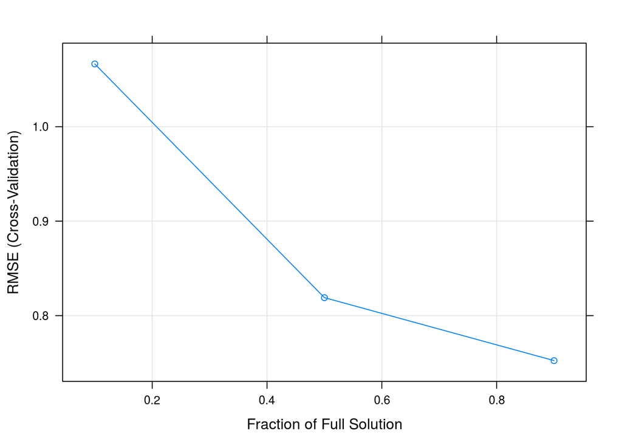

```r
treino_labels = prostate.train[, 10] ## Classes das instâncias de treino
treino = prostate.train[c(2,3,5,6)] ## Exclui variável alvo

con <- trainControl(method="cv", number=10)

lassoFit <- train(treino, treino_labels, method= "lasso", metric="RMSE",  trControl = con)


plot(lassoFit)
```

```r
lassoFit
```

```
## The lasso
##
## 67 samples
##  4 predictors
##
## No pre-processing
## Resampling: Cross-Validated (10 fold)
##
## Summary of sample sizes: 61, 60, 60, 61, 59, 62, ...
##
## Resampling results across tuning parameters:
##
##   fraction  RMSE       Rsquared   RMSE SD    Rsquared SD
##   0.1       1.0664612  0.6174823  0.2869788  0.1639269
##   0.5       0.8190214  0.6645981  0.2216896  0.1829279
##   0.9       0.7523764  0.7122103  0.1500642  0.2169375
##
## RMSE was used to select the optimal model using  the smallest value.
## The final value used for the model was fraction = 0.9.
```

Depois de criado o modelo iremos agora gerar a previsão

```r
train <- prostate.teste[c(2,3,5,6)]

lasso_prediction <- predict(lassoFit, train)

toPlot <- data.frame(esperado = prostate.teste$lpsa,
                     previsto = lasso_prediction)

residuos <- toPlot$esperado - toPlot$previsto

lasso_rmse <- RMSE(toPlot$previsto, toPlot$esperado)
lasso_rmse
```

```
## [1] 0.6662196
```

Comparando o RMSE do melhor modelo utilizando regressão linear x regressão linear com cross validation x lasso

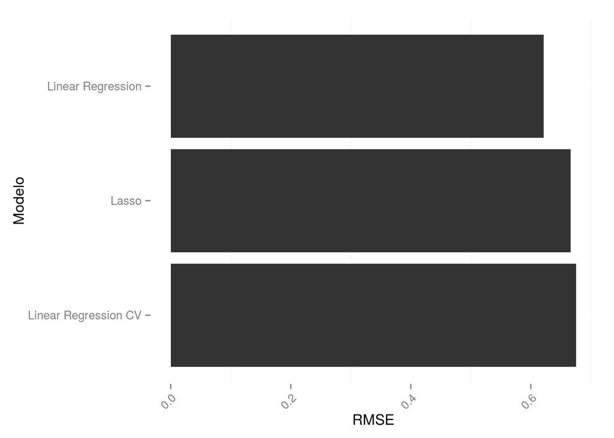

```r
toPlot <- data.frame(RMSE = c(linear_rmse, lmfit_rmse, lasso_rmse),
                     Modelo = c("Linear Regression", "Linear Regression CV", "Lasso"))


ggplot(toPlot, aes(x=reorder(Modelo, -RMSE), y=RMSE)) +
  geom_bar(stat="identity") +
  labs(x='Modelo', y='RMSE') +
   theme(axis.text.x = element_text(angle = 45, hjust = 1), panel.background=element_blank()) +
  coord_flip()
```

O melhor modelo será aquele que possuir o RMSE mais baixo. Utilizando essa métrica o melhor modelo gerado foi o utilizando linear regression sem o cross validation.